# DS202 Lab 5

Aaron Jencks, Eli Musgrove

4/11/2020

## Data Background

```r
acc = read_csv("https://raw.githubusercontent.com/xdaiISU/ds202materials/master/hwlabs/fars2017/accident.csv")  #, stringsAsFactors = FALSE)
person = read_csv("https://raw.githubusercontent.com/xdaiISU/ds202materials/master/hwlabs/fars2017/person.csv")  #, stringAsFactors = FALSE)
str(acc)
```

```
## Classes 'spec_tbl_df', 'tbl_df', 'tbl' and 'data.frame': 34247 obs. of  52 variables:
##  $ STATE     : num  1 1 1 1 1 1 1 1 1 1 ...
##  $ ST_CASE   : num  10001 10002 10003 10004 10005 ...
##  $ VE_TOTAL  : num  1 1 3 1 1 2 2 1 1 1 ...
##  $ VE_FORMS  : num  1 1 3 1 1 2 2 1 1 1 ...
##  $ PVH_INVL  : num  0 0 0 0 0 0 0 0 0 0 ...
##  $ PEDS      : num  0 0 0 0 0 0 0 0 0 1 ...
##  $ PERNOTMVIT: num  0 0 0 0 0 0 0 0 0 1 ...
##  $ PERMVIT   : num  1 1 3 1 2 4 2 1 1 1 ...
##  $ PERSONS   : num  1 1 3 1 2 4 2 1 1 1 ...
##  $ COUNTY    : num  73 89 101 73 13 49 73 3 87 73 ...
##  $ CITY      : num  330 1730 2130 350 0 0 350 0 0 0 ...
##  $ DAY       : num  19 14 31 1 1 6 11 11 11 14 ...
##  $ MONTH     : num  2 2 1 1 1 1 1 1 1 1 ...
##  $ YEAR      : num  2017 2017 2017 2017 2017 ...
##  $ DAY_WEEK  : num  1 3 3 1 1 6 4 4 4 7 ...
##  $ HOUR      : num  23 14 20 16 20 18 17 16 14 4 ...
##  $ MINUTE    : num  35 59 31 55 0 40 57 50 30 0 ...
##  $ NHS       : num  1 1 1 0 1 1 1 1 1 1 ...
##  $ RUR_URB   : num  2 2 2 2 1 1 2 1 1 2 ...
##  $ FUNC_SYS  : num  1 1 1 4 1 1 1 1 1 1 ...
##  $ RD_OWNER  : num  1 1 1 4 1 1 1 1 1 1 ...
##  $ ROUTE     : num  1 1 1 6 1 1 1 1 1 1 ...
##  $ TWAY_ID   : chr  "I-459" "I-565" "I-85" "20TH ST ENSLEY" ...
##  $ TWAY_ID2  : chr  NA NA "CHANTILLY PKWY" "AVE I" ...
##  $ MILEPT    : num  10 70 100 0 1383 ...
##  $ LATITUDE  : num  33.3 34.7 32.4 33.5 31.9 ...
##  $ LONGITUD  : num  -87 -86.8 -86.1 -86.9 -86.6 ...
##  $ SP_JUR    : num  0 0 0 0 0 0 0 0 0 0 ...
##  $ HARM_EV   : num  38 1 12 30 35 34 12 35 21 8 ...
##  $ MAN_COLL  : num  0 0 1 0 0 0 1 0 0 0 ...
##  $ RELJCT1   : num  0 0 0 0 0 0 0 0 0 0 ...
##  $ RELJCT2   : num  1 1 1 3 1 1 1 1 1 1 ...
##  $ TYP_INT   : num  1 1 1 2 1 1 1 1 1 1 ...
##  $ WRK_ZONE  : num  0 0 0 0 0 0 0 0 0 0 ...
##  $ REL_ROAD  : num  3 3 1 4 3 3 1 4 3 1 ...
##  $ LGT_COND  : num  2 1 2 3 2 2 1 1 1 2 ...
##  $ WEATHER1  : num  1 1 1 2 2 10 1 1 1 1 ...
##  $ WEATHER2  : num  0 0 0 0 0 0 0 0 0 0 ...
##  $ WEATHER   : num  1 1 1 2 2 10 1 1 1 1 ...
```

[output cut: 53 more lines]

```
##   ..   WEATHER = col_double(),
##   ..   SCH_BUS = col_double(),
##   ..   RAIL = col_character(),
##   ..   NOT_HOUR = col_double(),
##   ..   NOT_MIN = col_double(),
##   ..   ARR_HOUR = col_double(),
##   ..   ARR_MIN = col_double(),
##   ..   HOSP_HR = col_double(),
##   ..   HOSP_MN = col_double(),
##   ..   CF1 = col_double(),
##   ..   CF2 = col_double(),
##   ..   CF3 = col_double(),
##   ..   FATALS = col_double(),
##   ..   DRUNK_DR = col_double()
##   .. )
```

```r
str(person)
```

```
## Classes 'spec_tbl_df', 'tbl_df', 'tbl' and 'data.frame': 84921 obs. of  68 variables:
##  $ STATE     : num  1 1 1 1 1 1 1 1 1 1 ...
##  $ ST_CASE   : num  10001 10002 10003 10003 10003 ...
##  $ VE_FORMS  : num  1 1 3 3 3 1 1 1 2 2 ...
##  $ VEH_NO    : num  1 1 1 2 3 1 1 1 1 2 ...
##  $ PER_NO    : num  1 1 1 1 1 1 1 2 1 1 ...
##  $ STR_VEH   : num  0 0 0 0 0 0 0 0 0 0 ...
##  $ COUNTY    : num  73 89 101 101 101 73 13 13 49 49 ...
##  $ DAY       : num  19 14 31 31 31 1 1 1 6 6 ...
##  $ MONTH     : num  2 2 1 1 1 1 1 1 1 1 ...
##  $ HOUR      : num  23 14 20 20 20 16 20 20 18 18 ...
##  $ MINUTE    : num  35 59 31 31 31 55 0 0 40 40 ...
##  $ RUR_URB   : num  2 2 2 2 2 2 1 1 1 1 ...
##  $ FUNC_SYS  : num  1 1 1 1 1 4 1 1 1 1 ...
##  $ HARM_EV   : num  38 1 12 12 12 30 35 35 34 34 ...
##  $ MAN_COLL  : num  0 0 1 1 1 0 0 0 0 0 ...
##  $ SCH_BUS   : num  0 0 0 0 0 0 0 0 0 0 ...
##  $ MAKE      : num  20 37 82 2 84 30 12 12 49 14 ...
##  $ MAK_MOD   : num  20421 37402 82881 2404 84884 ...
##  $ BODY_TYP  : num  15 14 66 14 66 4 34 34 4 4 ...
##  $ MOD_YEAR  : num  2004 2005 2007 2003 2015 ...
##  $ TOW_VEH   : num  1 0 1 0 1 0 0 0 0 0 ...
##  $ SPEC_USE  : num  0 0 0 0 0 0 0 0 0 0 ...
##  $ EMER_USE  : num  0 0 0 0 0 0 0 0 0 0 ...
##  $ ROLLOVER  : num  0 9 0 0 0 1 1 1 1 0 ...
##  $ IMPACT1   : num  12 0 12 6 6 11 12 12 11 11 ...
##  $ FIRE_EXP  : num  0 0 1 0 0 0 0 0 0 0 ...
##  $ AGE       : num  42 43 63 47 64 18 67 17 18 37 ...
##  $ SEX       : num  1 1 1 1 1 1 2 1 2 2 ...
##  $ PER_TYP   : num  1 1 1 1 1 1 1 2 1 1 ...
##  $ INJ_SEV   : num  4 4 0 4 0 4 4 3 4 3 ...
##  $ SEAT_POS  : num  11 11 11 11 11 11 11 13 11 11 ...
##  $ REST_USE  : num  20 3 3 3 3 3 3 3 20 3 ...
##  $ REST_MIS  : num  0 0 0 0 0 0 0 0 0 0 ...
##  $ AIR_BAG   : num  1 8 20 99 20 8 1 20 20 20 ...
##  $ EJECTION  : num  1 0 0 0 0 0 0 0 1 0 ...
##  $ EJ_PATH   : num  9 0 0 0 0 0 0 0 9 0 ...
##  $ EXTRICAT  : num  0 0 0 0 0 0 0 0 0 0 ...
##  $ DRINKING  : num  0 9 0 0 0 9 0 8 0 0 ...
##  $ ALC_DET   : num  9 9 9 9 9 9 9 9 9 9 ...
```

[output cut: 85 more lines]

```
##   ..   DEATH_MO = col_double(),
##   ..   DEATH_YR = col_double(),
##   ..   DEATH_HR = col_double(),
##   ..   DEATH_MN = col_double(),
##   ..   DEATH_TM = col_double(),
##   ..   LAG_HRS = col_double(),
##   ..   LAG_MINS = col_double(),
##   ..   P_SF1 = col_double(),
##   ..   P_SF2 = col_double(),
##   ..   P_SF3 = col_double(),
##   ..   WORK_INJ = col_double(),
##   ..   HISPANIC = col_double(),
##   ..   RACE = col_double(),
##   ..   LOCATION = col_double()
##   .. )
```

## Part One

1. Are there some days of the week where more accidents happen than on others?

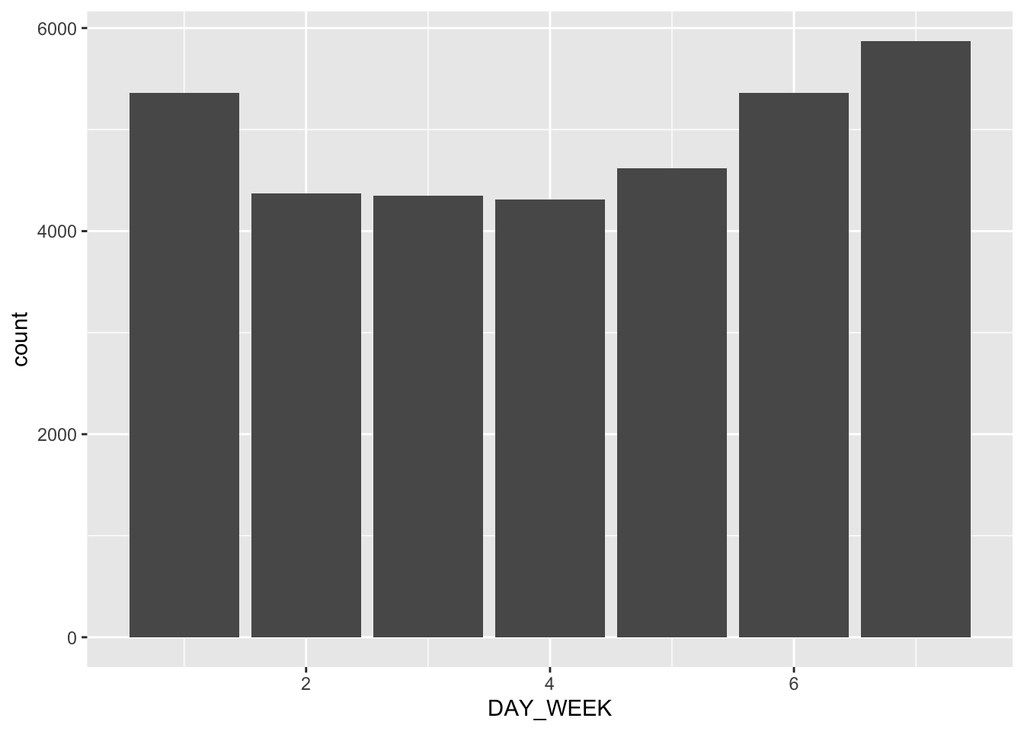

```r
ggplot(acc, aes(x=DAY_WEEK)) + geom_bar()
```

There are definitely more accidents on the weekends than on other days of the weeks, thought, it would seem that Thursday and Friday also represent slightly higher counts than others.

2. What time of the day to accidents happen?

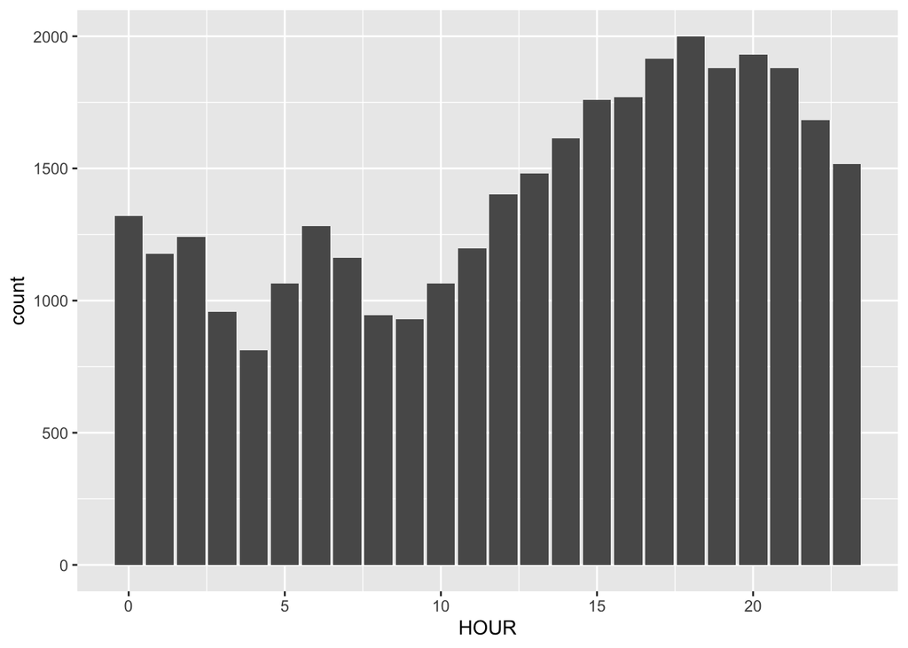

```r
acc = acc %>% filter(HOUR < 25)
ggplot(acc, aes(x=HOUR)) + geom_bar()
```

3. What is the number of accidents with at least one drunk driver?

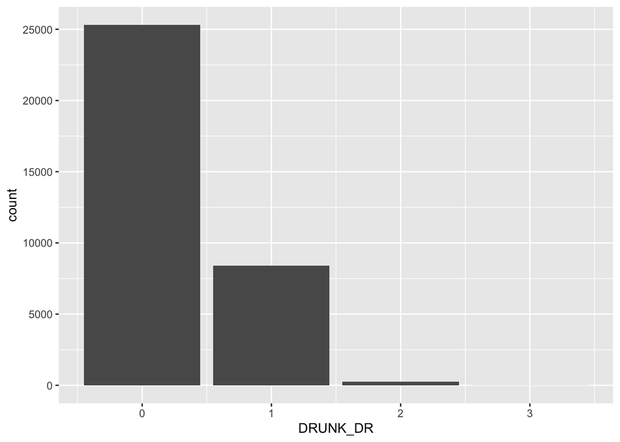

```r
ggplot(acc, aes(x=DRUNK_DR)) + geom_bar()
```

```r
sum(acc$DRUNK_DR > 0)
```

```
## [1] 8667
```

There are roughly 8667 accidents involving at least one drunk driver

## Part Two

4. In the `person` table, identify drivers and subset them

```r
# names(person)
# names(acc)
drivers = person %>% filter(PER_TYP == 1)
# str(drivers)
```

5. Join accident and person table.

```r
joined = left_join(acc, person, by = "ST_CASE")
str(joined)
```

```
## Classes 'spec_tbl_df', 'tbl_df', 'tbl' and 'data.frame': 84513 obs. of  119 variables:
##  $ STATE.x   : num  1 1 1 1 1 1 1 1 1 1 ...
##  $ ST_CASE   : num  10001 10002 10003 10003 10003 ...
##  $ VE_TOTAL  : num  1 1 3 3 3 1 1 1 2 2 ...
##  $ VE_FORMS.x: num  1 1 3 3 3 1 1 1 2 2 ...
##  $ PVH_INVL  : num  0 0 0 0 0 0 0 0 0 0 ...
##  $ PEDS      : num  0 0 0 0 0 0 0 0 0 0 ...
##  $ PERNOTMVIT: num  0 0 0 0 0 0 0 0 0 0 ...
##  $ PERMVIT   : num  1 1 3 3 3 1 2 2 4 4 ...
##  $ PERSONS   : num  1 1 3 3 3 1 2 2 4 4 ...
##  $ COUNTY.x  : num  73 89 101 101 101 73 13 13 49 49 ...
##  $ CITY      : num  330 1730 2130 2130 2130 350 0 0 0 0 ...
##  $ DAY.x     : num  19 14 31 31 31 1 1 1 6 6 ...
##  $ MONTH.x   : num  2 2 1 1 1 1 1 1 1 1 ...
##  $ YEAR      : num  2017 2017 2017 2017 2017 ...
```

[output cut: 86 more lines]

6. Tally the number of accidents by day of the week and gender. Visualize the results.

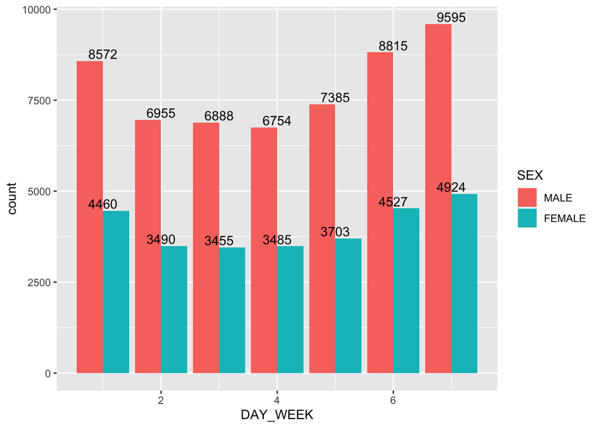

```r
summ = joined %>% mutate(SEX = factor(SEX, levels=c(1, 2), labels=c('MALE', 'FEMALE'))) %>% filter(!is.na(SEX)) %>% group_by(DAY_WEEK, SEX) %>% summarize(count=n())
ggplot(summ, aes(x=DAY_WEEK, y=count, fill=SEX, label=count)) + geom_bar(stat="identity", position="dodge") + geom_text(vjust=-0.25)
```

## Part Three

7. Now plot a chloropleth map of accidents on a county level
   - Read the description for `STATE` and `COUNTY` columns in the manual. The state & county codes are Geographic Locator Codes from [the General Services Acministration’s GSA publication](https://www.gsa.gov/reference/geographic-locator-codes/glcs-for-the-us-and-us-territories)
   - Use `readxl::read_xlsx` to read in the GLCs.

```r
# Load maps, get state and county lines
suppressMessages(suppressWarnings(library(maps)))
suppressMessages(suppressWarnings(library(mapproj)))
county = map_data('county')

# Read glc data ignoring datatype warnings
glc = suppressMessages(suppressWarnings(readxl::read_excel('glc.xlsx', sheet='GeoLocation_UnitedStates')))
glc$'State Code' = as.numeric(glc$'State Code')
glc$'County Code' = as.numeric(glc$'County Code')
glc$'County Name' = tolower(glc$'County Name')
glc$'State Name' = tolower(glc$'State Name')
```

8. Visualize the number of accidents in each county using a chloropleth map. To do this, you need to join the accident data, GLCs, and appropriate map date.

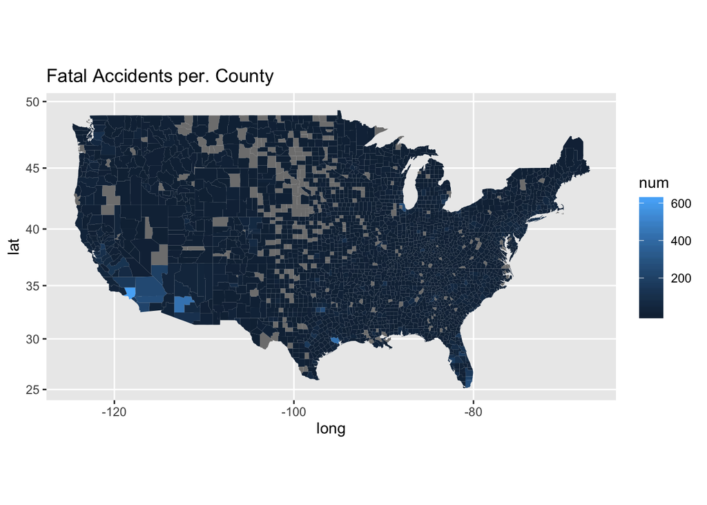

```r
# Join data
acc_counties = acc %>% group_by(STATE, COUNTY) %>% summarize(num=n()) %>% select(STATE, COUNTY, num)
final_data = glc %>% left_join(acc_counties, by=c('State Code' = 'STATE', 'County Code' = 'COUNTY')) %>% right_join(county, by=c('State Name' = 'region', 'County Name' = 'subregion'))

# Plot ech county
ggplot(final_data, aes(x=long, y=lat, fill=num)) + geom_polygon(aes(group=group)) + coord_map() + ggtitle('Fatal Accidents per. County')
```

9. Can you find seasonal trends in accident occurrences in different states? Is summer or winter more dangerous? Why?

##### In the summer, certain states have a large rise in accidents compared to their respective average while others have a large drop. For Florida, it is a state that is a common vacation destination in the winter. This means there are a large number of additional drivers on the road during this time. In Iowa and Maine, however, 2 cold states, there is more travel during the summer. I believe this is a larger factor than the possible weather during these times. Florida rarely gets snow, so this is unlikely a factor in the increased fatality rates in winter months. Iowa and Main, both cold states, have the rise in the summer, so weather is also not a factor during these times.

[figure not shown]

```r
seasonal_accidents = acc %>% select(STATE, MONTH) %>% left_join(glc, by=c('STATE' = 'State Code')) %>% rename('state_name' = 'State Name') %>% filter(state_name %in% c('iowa', 'florida', 'maine')) %>% group_by(state_name, MONTH) %>% mutate(num = n()) %>% ungroup()

seasonal_accidents %>% group_by(state_name, MONTH) %>% ggplot(aes(x=MONTH, fill=num)) + geom_bar() + facet_wrap(~state_name) + ylab('Number of fatal accidents') + xlab('Month') + ggtitle('Fatal Accidents')
```